# Creative Gaming: Propensity Modeling for Ad Targeting

## Part 4: Better Data, Better Predictions

```r
# Q1. Retrain the logistic regression model from Part 2 (which was trained on
#“cg_organic_train”) on the sample of customers who were exposed to the ad
#campaign (“cg_ad_random”). Instead of creating separate training/test datasets,
#please use the full 30,000 sample “cg_ad_random" you created in Part 3, Q2 to
#train the model.

model_log.1 <- glm(formula,
               family = "binomial", cg_ad_random)
summary(model_log.1)
```

```
Call:
glm(formula = formula, family = "binomial", data = cg_ad_random)

Coefficients:
                          Estimate Std. Error z value Pr(>|z|)
(Intercept)             -3.616e+00  9.965e-02 -36.289  < 2e-16 ***
GameLevel                5.295e-02  7.514e-03   7.046 1.84e-12 ***
NumGameDays              1.526e-02  2.961e-03   5.155 2.53e-07 ***
NumGameDays4Plus         8.536e-03  5.279e-03   1.617  0.10588
NumInGameMessagesSent   -1.782e-04  2.108e-04  -0.845  0.39787
NumSpaceHeroBadges       2.144e-02  7.944e-03   2.699  0.00695 **
NumFriendRequestIgnored  3.430e-05  6.589e-04   0.052  0.95848
NumFriends               1.841e-03  1.677e-04  10.983  < 2e-16 ***
AcquiredSpaceship1       8.782e-02  4.097e-02   2.143  0.03208 *
AcquiredIonWeapon1      -1.287e-01  1.386e-01  -0.929  0.35308
TimesLostSpaceship      -6.294e-03  2.006e-03  -3.138  0.00170 **
TimesKilled             -1.293e-03  5.361e-03  -0.241  0.80947
TimesCaptain             5.998e-03  2.011e-03   2.983  0.00285 **
TimesNavigator          -2.006e-03  2.537e-03  -0.791  0.42917
PurchasedCoinPackSmall1  3.522e-02  3.813e-02   0.924  0.35564
PurchasedCoinPackLarge1  1.620e-01  4.071e-02   3.980 6.88e-05 ***
NumAdsClicked            8.908e-02  2.247e-03  39.636  < 2e-16 ***
DaysUser                 2.064e-05  2.796e-05   0.738  0.46049
UserNoConsole1           5.037e-02  4.890e-02   1.030  0.30303
UserHasOldOS1           -2.057e-01  6.807e-02  -3.022  0.00251 **
---
Signif. codes:  0 '***' 0.001 '**' 0.01 '*' 0.05 '.' 0.1 ' ' 1

(Dispersion parameter for binomial family taken to be 1)

    Null deviance: 23233  on 29999  degrees of freedom
Residual deviance: 21040  on 29980  degrees of freedom
AIC: 21080

Number of Fisher Scoring iterations: 5
```

```r
confint(model_log.1)
```

```
                                2.5 %        97.5 %
(Intercept)             -3.812422e+00 -3.421765e+00
GameLevel                3.825122e-02  6.770712e-02
NumGameDays              9.465151e-03  2.107203e-02
NumGameDays4Plus        -1.879026e-03  1.881879e-02
NumInGameMessagesSent   -5.944137e-04  2.318237e-04
NumSpaceHeroBadges       5.720958e-03  3.686673e-02
NumFriendRequestIgnored -1.260836e-03  1.322079e-03
NumFriends               1.511231e-03  2.168587e-03
AcquiredSpaceship1       7.290974e-03  1.679031e-01
AcquiredIonWeapon1      -4.081037e-01  1.357483e-01
TimesLostSpaceship      -1.034384e-02 -2.500109e-03
TimesKilled             -1.296190e-02  8.224852e-03
TimesCaptain             1.981970e-03  9.887262e-03
TimesNavigator          -7.255347e-03  2.846698e-03
PurchasedCoinPackSmall1 -3.967430e-02  1.097920e-01
PurchasedCoinPackLarge1  8.197649e-02  2.415619e-01
NumAdsClicked            8.467838e-02  9.348855e-02
DaysUser                -3.419916e-05  7.541044e-05
UserNoConsole1          -4.610654e-02  1.456159e-01
UserHasOldOS1           -3.408730e-01 -7.394419e-02
```

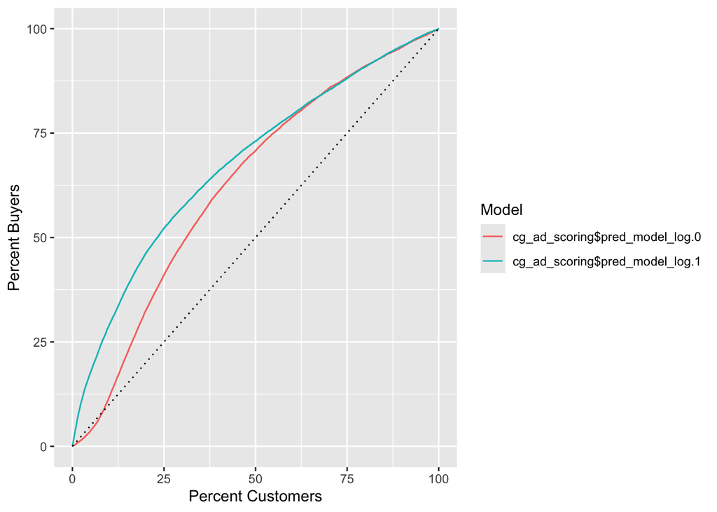

```
# A tibble: 2 × 2
  model                            auc
  <chr>                          <dbl>
1 cg_ad_scoring$pred_model_log.0 0.644
2 cg_ad_scoring$pred_model_log.1 0.703
```

```r
#Q2.Compare the performance of the original “organic” model from Part 2 and this
#new “ad” model on the “cg_ad_scoring” sample you created in Part 3, Q3. Use
#gains curves and AUC to make the comparison. What do you find?

cg_ad_scoring %>%
  mutate(pred_model_log.1 = predict(model_log.1,
                              newdata = cg_ad_scoring,
                              type = "response")) -> cg_ad_scoring
gainsplot(cg_ad_scoring$pred_model_log.0,
          cg_ad_scoring$pred_model_log.1,
          label.var=cg_ad_scoring$converted)
```

#The performance of the new model improves considerably, specially in the “lower part of #the curve”. This is reflected in the AUC which raises to 0.703.

```r
#Q3. Calculate the profit improvement of using the “ad” model instead of the “organic”
#model to target the best 30,000 customers in the “cg_ad_scoring” sample.

# Helper: profit from targeting the 30,000 highest-scoring customers
# ($14.99 per conversion, $1.50 per ad served)
profit_top30k <- function(scores) {
  top <- cg_ad_scoring[order(-scores)[1:30000], ]
  sum(top$converted == 1) * 14.99 - 30000 * 1.5
}

profit_organic_model <- profit_top30k(cg_ad_scoring$pred_model_log.0)
profit_ad_model      <- profit_top30k(cg_ad_scoring$pred_model_log.1)

data.frame(model = c("Organic model", "Ad model"),
           profit = round(c(profit_organic_model, profit_ad_model)))
```

```
          model profit
1 Organic model  51715
2      Ad model  78173
```

```r
cat("Profit improvement from the ad model: $", round(profit_ad_model - profit_organic_model), "\n")
```

```
Profit improvement from the ad model: $ 26457
```

#Targeting with the ad-trained model earns $78,173 vs. $51,715 with the organic model: +$26,457 (+51%).

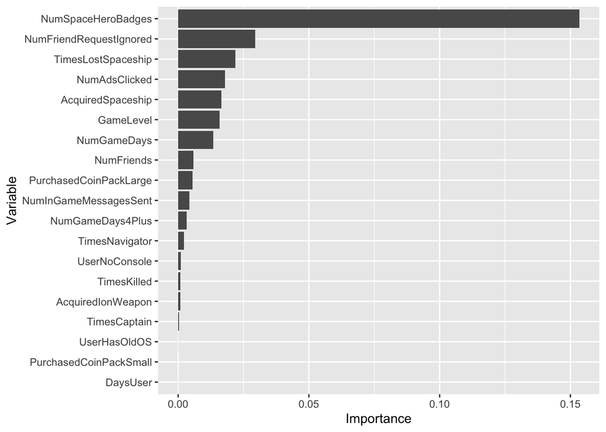

```r
#Q4. Compare the variable importance plot of the “organic” model and the “ad” model
#and explain why the performance of the models differs.

varimpplot(model_log.0, target = "converted", data = cg_organic_train)
```

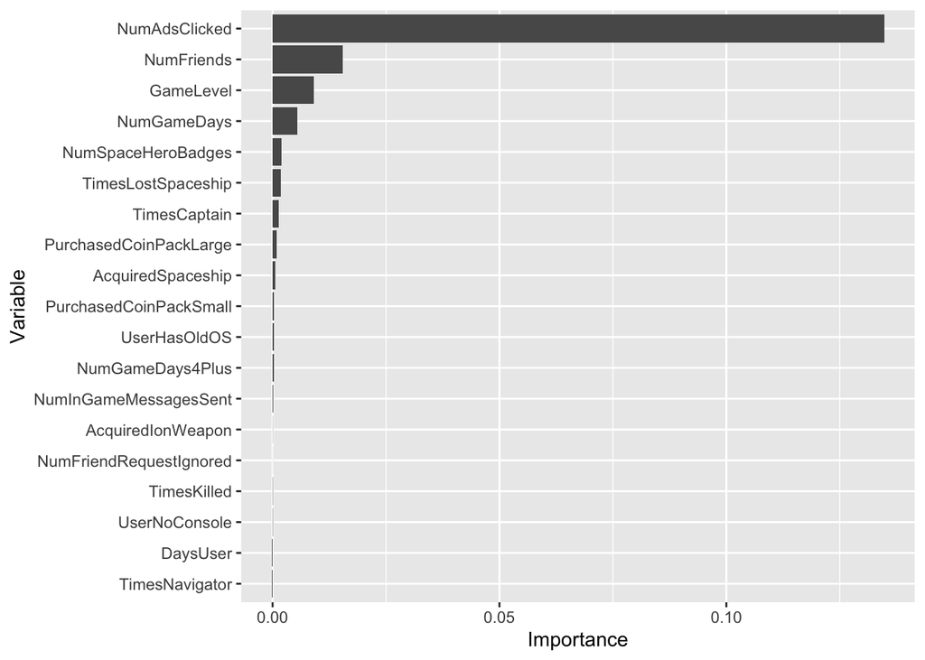

```r
varimpplot(model_log.1, target = "converted",
           data = cg_ad_random %>% mutate(converted = factor(converted)))
```

#Organic model: driven by in-game achievement (space hero badges, game level, ignored friend requests). #Ad model: driven by ad engagement (NumAdsClicked), then number of friends. #Once ads are shown, how a player responds to ads matters more than past in-game activity, so a model #trained on organic behavior ranks ad-exposed players poorly.

#Part 5: Better Models, Better Predictions #——————————————– #Q1. Train a random forest on the sample of customers who were exposed to the #ad campaign. (If you time, you can also try a neural network!). #Hints:- To train a random forest we use the ranger package (please install it first #and then load it in your R notebook).

```r
library(ranger)
set.seed(1234)

cg_ad_random_rf <- cg_ad_random %>% mutate(converted = factor(converted))

rf_ad <- ranger(converted ~ ., data = cg_ad_random_rf,
                probability = TRUE, num.trees = 500,
                mtry = 4, min.node.size = 50, importance = "impurity")

cg_ad_scoring <- cg_ad_scoring %>%
  mutate(pred_rf_ad = predict(rf_ad, data = cg_ad_scoring)$predictions[, 2])
```

#Q2. Compare the performance of the random forest “ad” model and the logistic #regression “ad” model from Part 4 on the “cg_ad_scoring” sample. Use #gains curves and AUC to make the comparison. What do you find?

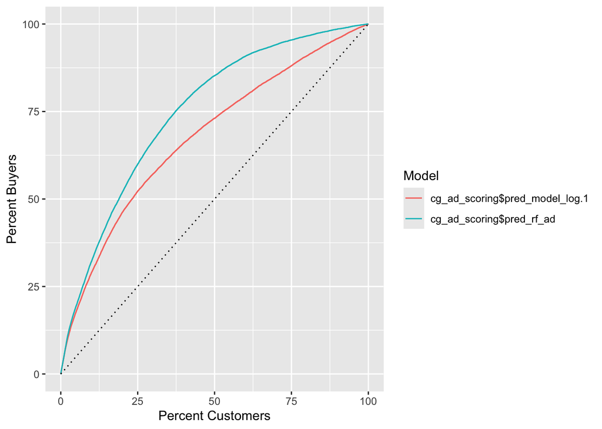

```
# A tibble: 2 × 2
  model                            auc
  <chr>                          <dbl>
1 cg_ad_scoring$pred_model_log.1 0.703
2 cg_ad_scoring$pred_rf_ad       0.785
```

```r
gainsplot(cg_ad_scoring$pred_model_log.1,
          cg_ad_scoring$pred_rf_ad,
          label.var = cg_ad_scoring$converted)
```

#The random forest beats the logistic regression: AUC 0.785 vs. 0.703. #It captures non-linear effects and interactions that a logistic model misses.

#Q3. Calculate the profit improvement of using the random forest “ad” model and #the logistic regression “ad” model to target the best 30,000 customers in the #“cg_ad_scoring” sample.

```r
profit_rf_ad <- profit_top30k(cg_ad_scoring$pred_rf_ad)

data.frame(model = c("Organic model (logistic)", "Ad model (logistic)", "Ad model (random forest)"),
           profit = round(c(profit_organic_model, profit_ad_model, profit_rf_ad)))
```

```
                     model profit
1 Organic model (logistic)  51715
2      Ad model (logistic)  78173
3 Ad model (random forest)  96446
```

```r
cat("Profit improvement, RF vs. ad logistic: $", round(profit_rf_ad - profit_ad_model), "\n")
```

```
Profit improvement, RF vs. ad logistic: $ 18273
```

```r
cat("Profit improvement, RF vs. organic logistic: $", round(profit_rf_ad - profit_organic_model), "\n")
```

```
Profit improvement, RF vs. organic logistic: $ 44730
```

#Random forest profit is $96,446: +$18,273 vs. the ad logistic model and +$44,730 vs. the organic model.